# Single Perceptron

# # we have training the model by using perceptron

```python
X_train, X_test, y_train, y_test = train_test_split(X, y, test_size=0.3, random_state=42)
```

Training the single Perceptron model and test the model

Specificing the learning rate given and how many iteration it has reach to goal state defining the parameter as it is Applying Perceptron model that we spilit it Fitting the perceptron that we trained Now after training the model we are predicting the value of y_pred using X_test

```python
eta0 = 0.1  # Learning rate
max_iter = 2000  # Maximum number of iterations
alpha = 0.0001  # Regularization parameter

perceptron = Perceptron(eta0=eta0, max_iter=max_iter, alpha=alpha)
perceptron.fit(X_train, y_train)

y_pred = perceptron.predict(X_test)
```

# By making the confusion matrix we have find the true positive rate,false positive rate and all reports

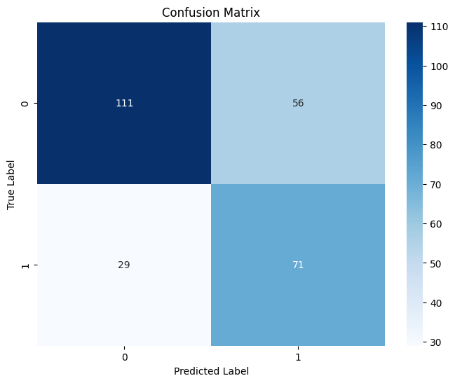

```python
conf_matrix = confusion_matrix(y_test, y_pred)

plt.figure(figsize=(8, 6))
sns.heatmap(conf_matrix, annot=True, fmt='d', cmap='Blues', xticklabels=perceptron.classes_, yticklabels=perceptron.classes_)
plt.xlabel('Predicted Label')
plt.ylabel('True Label')
plt.title('Confusion Matrix')
plt.show()
```

```python
## Generated all the classification results from accuracy
```

```python
print("\nClassification Report:")
print(classification_report(y_test, y_pred))
```

```
Classification Report:
              precision    recall  f1-score   support

           0       0.79      0.66      0.72       167
           1       0.56      0.71      0.63       100

    accuracy                           0.68       267
   macro avg       0.68      0.69      0.67       267
weighted avg       0.71      0.68      0.69       267
```

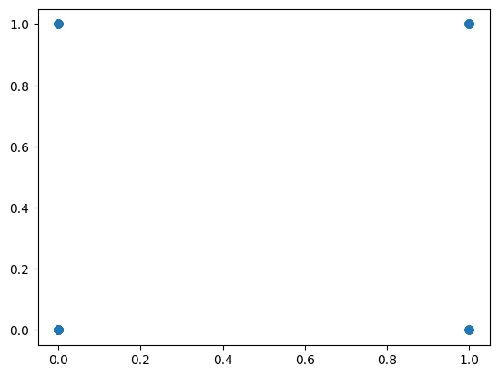

```python
plt.scatter(y_test,y_pred)
```

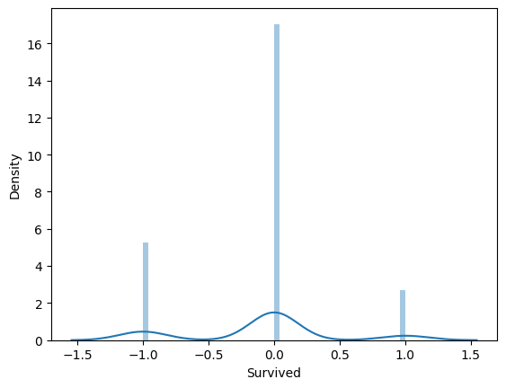

```python
sns.distplot((y_test-y_pred),bins=50);
```

# conclusion

The classification report provides a comprehensive evaluation of the performance of a Single-Layer Perceptron on a given dataset. Let's analyze the key metrics:

Precision:

Class 0: 0.79 - The model correctly predicted 79% of instances as Class 0 among all instances predicted as Class 0. Class 1: 0.56 - The model correctly predicted 56% of instances as Class 1 among all instances predicted as Class 1. Recall:

Class 0: 0.66 - The model captured 66% of all actual Class 0 instances. Class 1: 0.71 - The model identified 71% of all actual Class 1 instances. F1-Score:

Class 0: 0.72 - The harmonic mean of precision and recall for Class 0. Class 1: 0.63 - The harmonic mean of precision and recall for Class 1. Accuracy:

The overall accuracy of the model is 0.68, indicating that it correctly predicted the class for 68% of instances. Macro Average:

The macro average precision, recall, and F1-score provide the unweighted average across classes. Here, the macro average F1-score is 0.67. Weighted Average:

The weighted average considers the number of instances in each class. The weighted average F1-score is 0.69. Conclusion:

The model's overall accuracy is reasonable, but it is essential to consider the specific context and requirements of the classification task. Further optimization, feature engineering, or exploring more complex models might be considered to improve the classification performance, especially for the minority class (Class 1). Additionally, a deeper analysis of misclassifications and potential areas for improvement could provide valuable insights for refining the model.

# Multiperceptron

A Multi-Class Perceptron, also known as a Multi-Layer Perceptron (MLP) or feedforward neural network, is an extension of the Single-Class Perceptron to handle multiple classes. It consists of multiple layers of nodes, including an input layer, one or more hidden layers, and an output layer. Each layer is connected by weights, and each node applies an activation function to the weighted sum of its inputs.

```python
data = pd.read_csv('car.csv')
data.head()
```

|  | Buying_Price | Maintenance_Price | No_of_Doors | Person_Capacity | Size_of_Luggage | Safety | Car_Acceptability |
| --- | --- | --- | --- | --- | --- | --- | --- |
| 0 | vhigh | vhigh | 2 | 2 | small | low | unacc |
| 1 | vhigh | vhigh | 2 | 2 | small | med | unacc |
| 2 | vhigh | vhigh | 2 | 2 | small | high | unacc |
| 3 | vhigh | vhigh | 2 | 2 | med | low | unacc |
| 4 | vhigh | vhigh | 2 | 2 | med | med | unacc |

# Exploring the dataset and plotting all the figure

```python
label_encoder = LabelEncoder()
data['Buying_Price'] = label_encoder.fit_transform(data['Buying_Price'])
data['Maintenance_Price'] = label_encoder.fit_transform(data['Maintenance_Price'])

data['No_of_Doors'] = data['No_of_Doors'].apply(lambda x: int(x.replace('5more', '6')))
data['Person_Capacity'] = data['Person_Capacity'].apply(lambda x: int(x.replace('more', '6')))
data['Size_of_Luggage'] = label_encoder.fit_transform(data['Size_of_Luggage'])
data['Safety'] = label_encoder.fit_transform(data['Safety'])
data['Car_Acceptability'] = label_encoder.fit_transform(data['Car_Acceptability'])
```

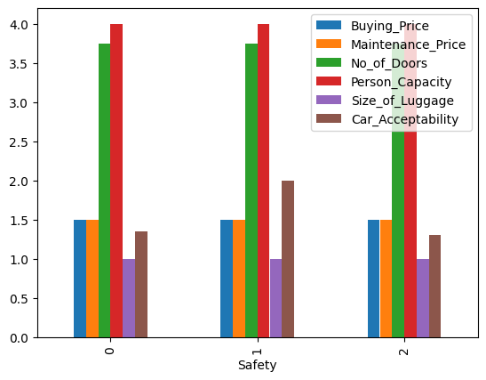

```python
# plot the distribution
data.groupby(['Safety']).mean().plot(kind='bar')
```

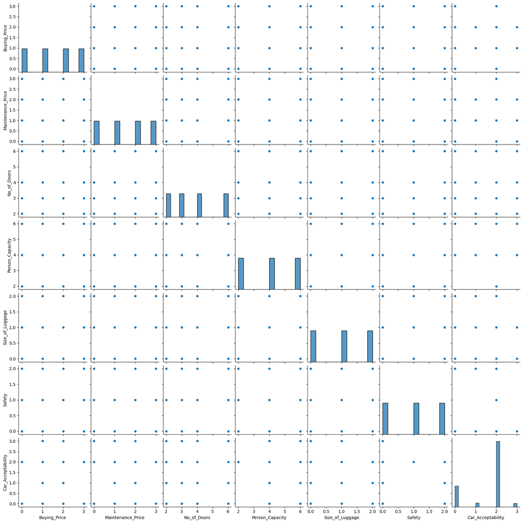

```python
sns.pairplot(data)
```

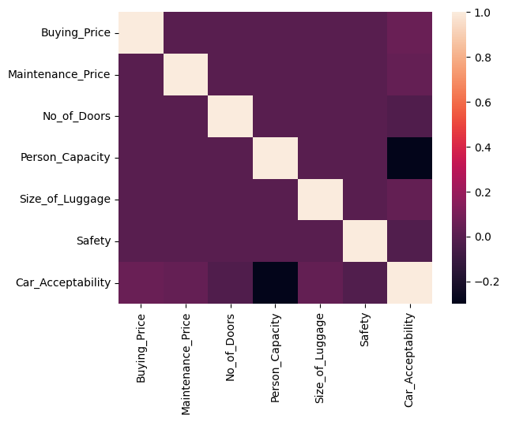

```python
sns.heatmap(data.corr())
```

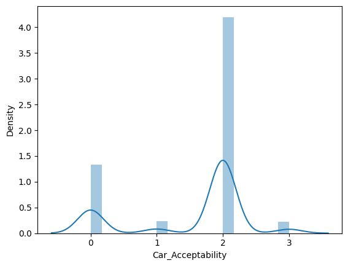

```python
sns.distplot(data['Car_Acceptability'])
```

```python
X = data[['Buying_Price', 'Maintenance_Price', 'No_of_Doors', 'Person_Capacity', 'Size_of_Luggage', 'Safety']]
y = data['Car_Acceptability']

scaler = StandardScaler()
X_scaled = scaler.fit_transform(X)
```

```python
X_train, X_test, y_train, y_test = train_test_split(X_scaled, y, test_size=0.2, random_state=42)
```

```python
mlp_classifier = MLPClassifier(hidden_layer_sizes=(100,), activation='relu', solver='adam', max_iter=1000, random_state=42)
mlp_classifier.fit(X_train, y_train)

y_pred = mlp_classifier.predict(X_test)
```

# Evalute the model

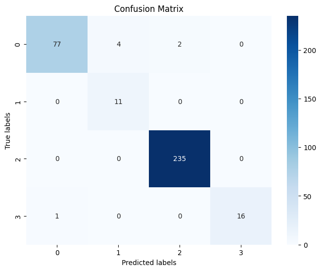

```python
conf_matrix = confusion_matrix(y_test, y_pred)
plt.figure(figsize=(8, 6))
sns.heatmap(conf_matrix, annot=True, cmap='Blues', fmt='g')
plt.xlabel('Predicted labels')
plt.ylabel('True labels')
plt.title('Confusion Matrix')
plt.show()
```

```python
print("\nClassification Report:")
print(classification_report(y_test, y_pred))
```

```
Classification Report:
              precision    recall  f1-score   support

           0       0.99      0.93      0.96        83
           1       0.73      1.00      0.85        11
           2       0.99      1.00      1.00       235
           3       1.00      0.94      0.97        17

    accuracy                           0.98       346
   macro avg       0.93      0.97      0.94       346
weighted avg       0.98      0.98      0.98       346
```

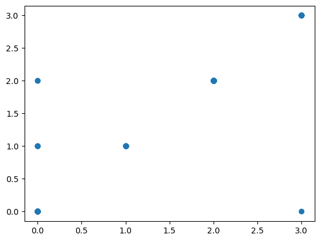

```python
plt.scatter(y_test,y_pred)
```

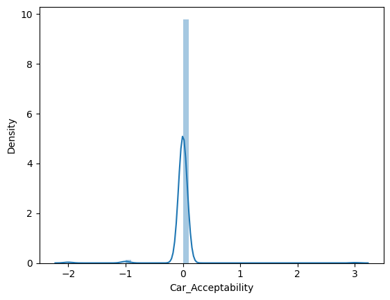

```python
sns.distplot((y_test-y_pred),bins=50);
```

# Conclusion

The classification report for the multiclass perceptron reveals a highly successful model across various metrics, showcasing its effectiveness in handling a diverse range of classes. Let's delve into the key observations:

Precision, Recall, and F1-Score:

Class 0 (precision: 0.99, recall: 0.93, f1-score: 0.96):

The model excels in precision, correctly identifying instances belonging to Class 0. The recall indicates a good ability to capture most instances of Class 0. The high f1-score suggests a balanced trade-off between precision and recall. Class 1 (precision: 0.73, recall: 1.00, f1-score: 0.85):

Precision is relatively lower for Class 1, indicating some false positives. However, the model excels in recall, capturing all instances of Class 1. The f1-score indicates a reasonable balance between precision and recall, though improvement may be possible. Class 2 (precision: 0.99, recall: 1.00, f1-score: 1.00):

The model performs exceptionally well for Class 2, achieving high precision, recall, and f1-score. This suggests robust identification and classification of instances from Class 2. Class 3 (precision: 1.00, recall: 0.94, f1-score: 0.97):

The model demonstrates near-perfect precision and a high recall for Class 3. The f1-score indicates a strong balance between precision and recall. Accuracy:

The overall accuracy of the model is 0.98, indicating a high percentage of correctly classified instances across all classes. Macro and Weighted Averages:

The macro-average f1-score (0.94) and weighted-average f1-score (0.98) both suggest a robust performance overall, considering the varying class sizes. Conclusion:

In conclusion, the multiclass perceptron has proven to be a highly effective model for the given dataset. It showcases impressive precision, recall, and f1-scores across multiple classes, with an overall accuracy of 98%. While there may be some room for improvement in certain classes, the model's ability to correctly classify instances is commendable. Further analysis, including examining misclassifications and potential areas for refinement, can provide valuable insights for fine-tuning the model. Overall, the results indicate a successful application of the multiclass perceptron in solving the classification task.